# Project

Teshale

2024-12-03

# Introduction

- This project aims to analyze board game data from BoardGameGeek to uncover insights regarding game popularity, player preferences, and trends. By understanding these patterns, we can identify what makes a board game successful and how preferences have evolved over the years.
- As the popularity of board games grows, there is a need to understand the factors that contribute to their success. This analysis seeks to uncover the patterns and trends in board game data, focusing on ratings, player count, and categories.
- We will use data from BoardGameGeek, including game ratings, categories, mechanics, and publication years. The analysis will involve data cleaning, exploratory data analysis (EDA), and visualization techniques to derive meaningful insights.
- The findings from this analysis can help game designers, publishers, and enthusiasts understand what makes a board game popular and how player preferences have changed over time.

# Data Preparation:

- Source: The data was obtained from Kaggle.
- (https://www.kaggle.com/code/devisangeetha/insights-geek-board-game/input).
- Data Explanation:
- The data is collected by BoardGameGeek, a popular online database for board games.
- To provide comprehensive information about board games, including ratings, categories, and mechanics.
- The dataset includes data up to April 2017.
- The data may contain missing values and entries that need to be cleaned for accurate analysis.

# Data import

```r
library(tidyverse)
#game_data <- read_csv("BGGdata.csv", show_col_types = FALSE)
game_data <- read_csv("bgg_db_2017_04.csv/bgg_db_2017_04.csv")
board_game <- read.csv("board_game_popularity_over_years.csv")
#artists_reduced <- read.csv("project/artists_reduced.csv/artists_reduced.csv")
glimpse(game_data)
```

```
## Rows: 4,999
## Columns: 20
## $ rank        <dbl> 1, 2, 3, 4, 5, 6, 7, 8, 9, 10, 11, 12, 13, 14, 15, 16, 17,…
## $ bgg_url     <chr> "https://boardgamegeek.com/boardgame/161936/pandemic-legac…
## $ game_id     <dbl> 161936, 182028, 12333, 120677, 174430, 187645, 169786, 167…
## $ names       <chr> "Pandemic Legacy: Season 1", "Through the Ages: A New Stor…
## $ min_players <dbl> 2, 2, 2, 2, 1, 2, 1, 1, 2, 1, 2, 2, 2, 1, 1, 2, 2, 2, 2, 1…
## $ max_players <dbl> 4, 4, 2, 5, 4, 4, 5, 5, 2, 7, 4, 5, 4, 5, 4, 4, 4, 5, 4, 5…
## $ avg_time    <dbl> 60, 240, 180, 150, 150, 240, 115, 120, 30, 210, 90, 150, 1…
## $ min_time    <dbl> 60, 180, 180, 60, 90, 180, 90, 90, 30, 30, 30, 90, 150, 30…
## $ max_time    <dbl> 60, 240, 180, 150, 150, 240, 115, 120, 30, 210, 90, 150, 1…
## $ year        <dbl> 2015, 2015, 2005, 2012, 2017, 2016, 2016, 2016, 2015, 2013…
## $ avg_rating  <dbl> 8.66905, 8.72977, 8.35745, 8.29627, 9.08970, 8.53049, 8.32…
## $ geek_rating <dbl> 8.48904, 8.30744, 8.22021, 8.15458, 8.15151, 8.15037, 8.08…
## $ num_votes   <dbl> 18009, 7309, 27403, 24267, 3978, 8696, 16199, 9749, 21195,…
## $ image_url   <chr> "https://cf.geekdo-images.com/images/pic2452831.png", "htt…
## $ age         <dbl> 13, 14, 13, 12, 12, 14, 14, 12, 10, 12, 12, 12, 13, 12, 14…
## $ mechanic    <chr> "Action Point Allowance System, Co-operative Play, Hand Ma…
## $ owned       <dbl> 29472, 10007, 37382, 27948, 6057, 14304, 21702, 11567, 334…
## $ category    <chr> "Environmental, Medical", "Card Game, Civilization, Econom…
## $ designer    <chr> "Rob Daviau, Matt Leacock", "Vlaada Chv\xe1til", "Ananda G…
## $ weight      <dbl> 2.8076, 4.3093, 3.5317, 3.9387, 3.7028, 3.5686, 3.3198, 3.…
```

```r
glimpse(board_game)
```

```
## Rows: 118
## Columns: 2
## $ yearpublished <dbl> 1901, 1902, 1903, 1904, 1905, 1906, 1907, 1908, 1909, 19…
## $ count         <int> 7, 9, 18, 20, 17, 11, 9, 11, 17, 59, 12, 15, 10, 12, 23,…
```

```r
#glimpse(artists_reduced)
```

# Exploratory Data Analysis:

- key statistics for game ratings, number of votes, and playing times.

```r
summary(game_data)
```

```
##       rank        bgg_url             game_id          names
##  Min.   :   1   Length:4999        Min.   :     1   Length:4999
##  1st Qu.:1250   Class :character   1st Qu.:  8205   Class :character
##  Median :2500   Mode  :character   Median : 43530   Mode  :character
##  Mean   :2500                      Mean   : 75692
##  3rd Qu.:3750                      3rd Qu.:144568
##  Max.   :4999                      Max.   :224316
##   min_players     max_players         avg_time          min_time
##  Min.   :0.000   Min.   :  0.000   Min.   :    0.0   Min.   :    0.00
##  1st Qu.:2.000   1st Qu.:  4.000   1st Qu.:   30.0   1st Qu.:   30.00
##  Median :2.000   Median :  4.000   Median :   60.0   Median :   45.00
##  Mean   :2.035   Mean   :  5.287   Mean   :  105.6   Mean   :   87.33
##  3rd Qu.:2.000   3rd Qu.:  6.000   3rd Qu.:  112.5   3rd Qu.:   90.00
##  Max.   :8.000   Max.   :999.000   Max.   :17280.0   Max.   :17280.00
##     max_time            year         avg_rating     geek_rating
##  Min.   :    0.0   Min.   :-3000   Min.   :5.734   Min.   :5.626
##  1st Qu.:   30.0   1st Qu.: 2002   1st Qu.:6.493   1st Qu.:5.704
##  Median :   60.0   Median : 2009   Median :6.880   Median :5.881
##  Mean   :  105.2   Mean   : 1996   Mean   :6.932   Mean   :6.064
##  3rd Qu.:  100.0   3rd Qu.: 2014   3rd Qu.:7.315   3rd Qu.:6.264
##  Max.   :17280.0   Max.   : 2018   Max.   :9.332   Max.   :8.489
##    num_votes      image_url              age          mechanic
##  Min.   :   47   Length:4999        Min.   : 0.00   Length:4999
##  1st Qu.:  231   Class :character   1st Qu.: 8.00   Class :character
##  Median :  509   Mode  :character   Median :10.00   Mode  :character
##  Mean   : 1698                      Mean   :10.29
##  3rd Qu.: 1368                      3rd Qu.:12.00
##  Max.   :68505                      Max.   :42.00
##      owned         category           designer             weight
##  Min.   :   12   Length:4999        Length:4999        Min.   :0.000
##  1st Qu.:  495   Class :character   Class :character   1st Qu.:1.736
##  Median :  980   Mode  :character   Mode  :character   Median :2.288
##  Mean   : 2536                                         Mean   :2.345
##  3rd Qu.: 2264                                         3rd Qu.:2.888
##  Max.   :96783                                         Max.   :4.905
```

# Distribution of Ratings:

- Understand the distribution of average ratings to identify common rating patterns.

1, the nunber of games in the dataset.

```
## [1] "Number of games: 4999"
```

2, the average minimum and maximum number of players.

```
## [1] "Average minimum number of players: 2.03460692138428"
```

```
## [1] "Average maximum number of players: 5.2872574514903"
```

3, Top 10 highest-rated board games.

```
## # A tibble: 10 × 2
##    names                                           avg_rating
##    <chr>                                                <dbl>
##  1 Mythic Battles: Pantheon                              9.33
##  2 Day Night Z                                           9.15
##  3 Gloomhaven                                            9.09
##  4 Gaia Project                                          8.91
##  5 Kingdom Death: Monster                                8.90
##  6 Last Chance for Victory                               8.86
##  7 Too Many Bones                                        8.86
##  8 Pandemonium                                           8.83
##  9 Last Blitzkrieg                                       8.82
## 10 The Greatest Day: Sword, Juno, and Gold Beaches       8.77
```

# 4, Plotting game ratings by player count.

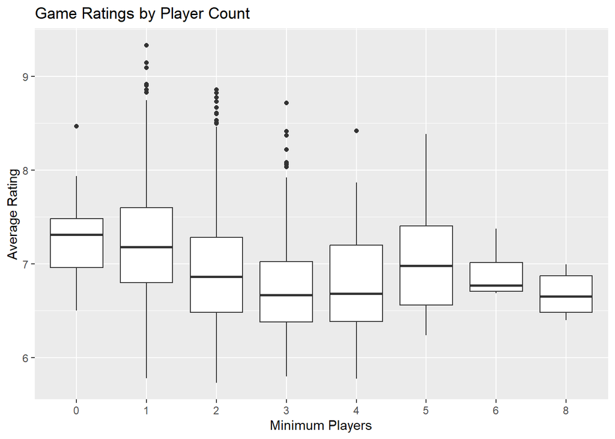

- Ratings tend to vary with the number of players, showing interesting trends in player preferences.

# 5, Scatter plot of player count vs. ratings.

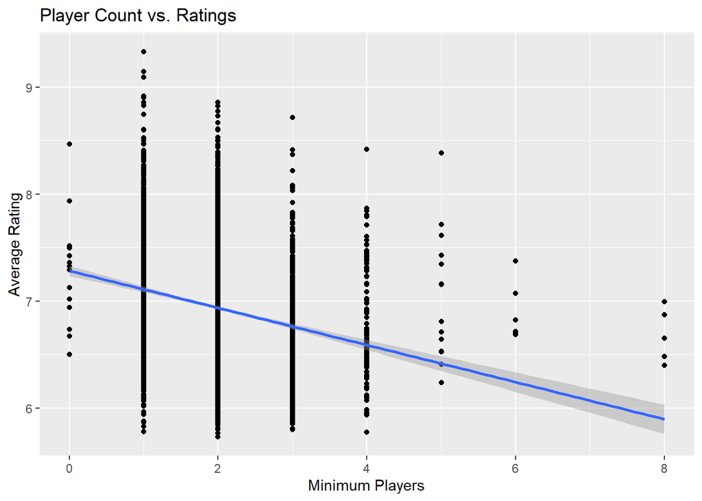

- The scatter plot and trend line reveal the correlation between player count and average rating.

# Publication Trends:

- Examine how the number of games published each year has changed over time.

1, the published of the game over a year

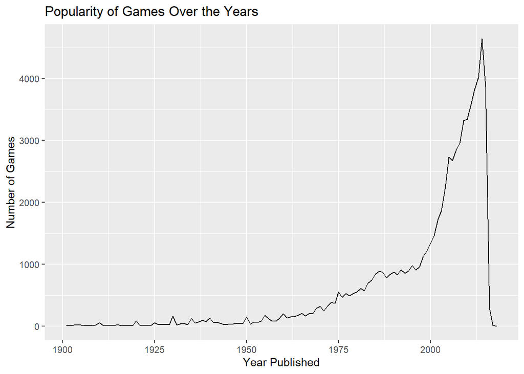

- There is a clear trend in the number of games published over the years.

# 2, Identify trends in game publication over the years.

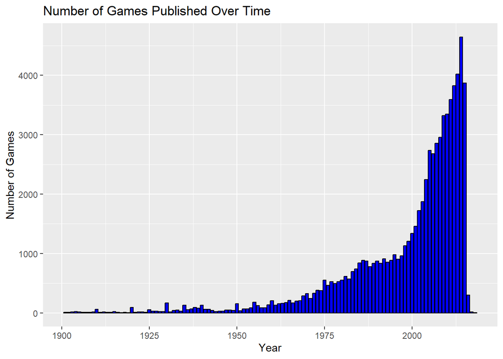

- The histogram shows trends and peaks in game publications over time.

# Category Breakdown:

- Analyze the proportion of different game categories to see which are the most popular.

1, the most 10 popular game categories?

```
##           category    n
## 1        Card Game 1362
## 2          Wargame 1025
## 3          Fantasy  681
## 4         Economic  531
## 5         Fighting  509
## 6  Science Fiction  453
## 7     World War II  371
## 8             Dice  344
## 9         Bluffing  332
## 10        Medieval  324
```